# Search

## Embedding derived from classification

### Data : words and their context (neighboring words ($\pm L$)

… lemon, a [tablespoon of apricot jam, a] pinch … c1 c2 w c3 c4

### Classification task

Given a tuple $(\boldsymbol w,\boldsymbol c) \in \mathbb R^d\times R^d$ of a target word $\boldsymbol w$ paired with a candidate context word $\boldsymbol c$ (for example (apricot, jam), or perhaps (apricot, aardvark)) return the probability that $c$ is a real context word (true for jam, false for aardvark):
$$P(y_{wc}=1 |\boldsymbol w, \boldsymbol c) = 1-P( y_{wc}=0 |\boldsymbol w, \boldsymbol c)$$

### Similarity

we rely on the intuition that two vectors are similar if they have a high dot product (after all, cosine is just a normalized dot product). In other words:
$$Similarity(\boldsymbol w,\boldsymbol c) = \boldsymbol c^T \boldsymbol w$$

## From dot product to logistic regression

### Logit

$$P(y_{wc}=1 |\boldsymbol w, \boldsymbol c) = \frac{1}{1+\exp(-\boldsymbol c^T \boldsymbol w)}$$

### Criterion

The criterion is a kind of likelihood including positive examples (observed association) and negative examples (non observed associations). In fact skip-gram with negative sampling (SGNS) uses more negative examples than positive examples (with the ratio between them set by a parameter $k$).

$$L = \sum_{ \boldsymbol w, \boldsymbol c : y_{wc} = 1} \log P(y_{wc} = 1| \boldsymbol w, \boldsymbol c) + \sum_{ \boldsymbol w', \boldsymbol c' : y_{w'c'} = 0} \log P(y_{w'c'} = 0 | \boldsymbol w', \boldsymbol c')$$

## Example

- The learning algorithm for skip-gram embeddings takes as input a corpus of text
- random embedding vector initialization for each of the N vocabulary words
- iteratively shift the embedding of each word $\boldsymbol w$ to be more like the context words

Let’s start by considering a single piece of training data:

… lemon, a [tablespoon of apricot jam, a] pinch …

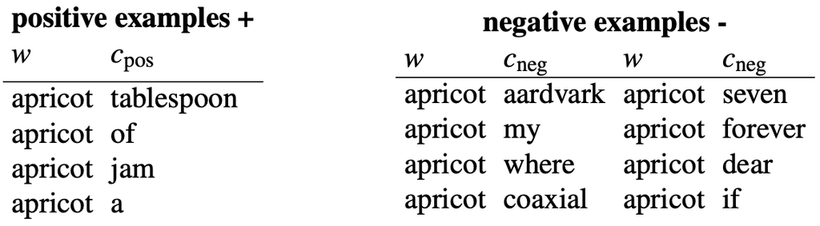

## Skip-gram model learns two separate embeddings

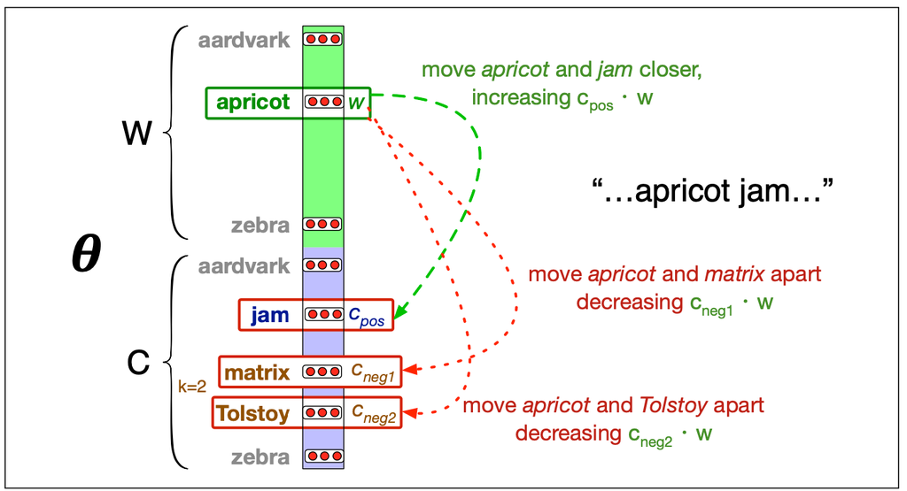

## Final embeddings

- skip-gram outputs the target matrix $W$ and the context matrix $C$.
- It’s common to just add them together, representing word i with the vector $\boldsymbol w_i + \boldsymbol c_i$.
- Alternatively we can throw away the C matrix and just represent each word i by the vector $\boldsymbol w_i$.
- As with the simple count-based methods like tf-idf, the context window size L affects the performance of skip-gram embeddings, and experiments often tune the parameter L on a devset.

# Transformers

## The nature of transformers

- Deep learning architecture based on **attention mechanisms**
- Weight the importance of different tokens in a sequence to **model long-range dependencies efficiently**

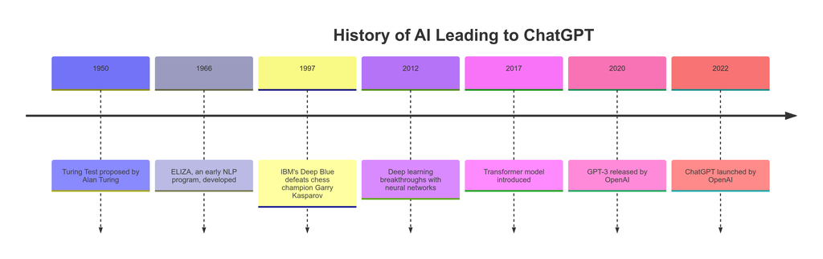

History of AI leading to chatGPT

## The nature of transformers

A classical transformer is a function
$$T(w_{1:n}) = \begin{bmatrix} p_1 \\
\vdots \\
p_{|V|}\end{bmatrix}$$

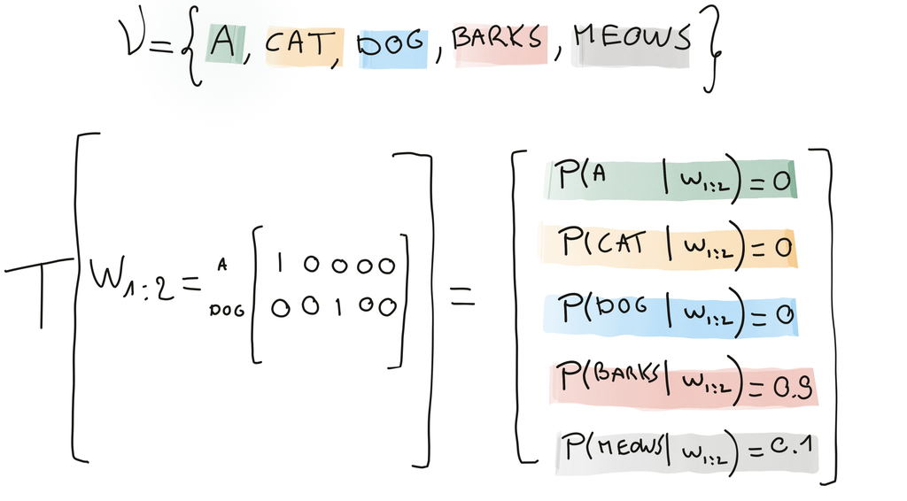

The nature of transformer

- $\mathcal V$ is a finite set (vocabulary) (Open AI uses 50,000 token as vocabulary)
- $w_{1:n}$ be a sequence of token, where each $w_i \in \mathcal V$ (In practice context varies from 1 to n, the blocksize)
- $p_j$ is the probability of $w_{(j)}$ the jth token in $\mathcal V$

### Remarks

- $w_{1:n}$ is usually coded a matrix of one-hot vectors with $w_{1:n} \in \mathbb{R}^{n \times |V|}$.
- For classical chatbot $p_j = P(w_{n+1} = w_{(j)} | w_{1:n})$ where $w_{(j)}$ is the jthe element of $\mathcal V$.

## Optimized criteria

Transformers typically optimize different criteria depending on the task they are trained on.

### Causal Language Modeling (CLM) / Autoregressive Loss

- **Used in:** GPT models
- **Objective:** Predict the next token given the previous tokens

The training set is a set of sequences $(s_j)$ of $n$ tokens $s_j=(w_1^j, w_2^j, \dots, w_n^j)$:

$$L_{CLM} = - \sum_j\sum_{t=1}^n \sum_{c\in V} I\!\!I_{w_t^j=c}\log P(w_t^j=c | w_{1:t-1}^j)$$
where $w_{1:t-1}^j$ denotes the tokens preceding position $t$ in the sequence $j$

The criterion is a kind of pseudo log-likelihood.

If nothing is learned each token has the same probability of appearing: the largest possible value of the criterion is
$$-\log\frac{1}{|V|}$$

## Masked Language Modeling (MLM)

- **Used in:** BERT models
- **Objective:** Predict randomly masked tokens in a sentence.

Let $M_j \subset \{1, \dots, n\}$ be the set of masked positions in the sequence $(s_j)$:

$$L_{MLM} = - \sum_j \sum_{t \in M_j} \sum_{c\in V} I\!\!I_{w_t^j=c} \log P(w_t^j=c | w^j_{(1:n)\backslash M})$$

## Conditional Language Modeling / Translation Loss

- **Used in:** T5, BART
- **Objective:** Predict an output sequence given an input sequence (e.g., translation, summarization).

Given input sequence $w^j = (w^j_1, \dots, w^j_n)$ and output sequence $v^j = (v^j_1, \dots, v^j_m)$:

$$L_{Seq2Seq} = - \sum_j \sum_{t=1}^m \sum_{c\in V} I\!\!I_{v_t^j=c} \log P(v_m^j=c | v^j_{1:m-1}, w^j_{1:n})$$

### Other losses

Transformers exact objective functions depends on type of considered problems

## Initial embedding

- The token are first embedded in a $d$ dimensional space (see previous topic)
- the representation $x_i= E w_i$ is independent of context.
- Let $X= x_{1:n} = w_{1:n} E^\top \in \mathbb{R}^{n \times d}$.

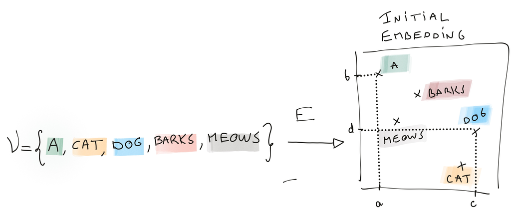

Initial embedding

## A minimal self-attention architecture for decoder

**Attention is a communication mecanism** between the tokens of a sequence.

Self attention proposes a contextual representation $h_i$ of $x_i$ as a linear combination the sequence:
$$h_i =V . \sum_{j=1}^n \alpha_{ij} x_j$$

- $h_i$ aggregates the past between query (current postion i) and key (other past position j)
  - $\sum_j \alpha_{ij}=1$
- In decoder the future cannot communicate with the past
  - $\forall j>i, \alpha_{ij}=0$
- the structure of the attention matrix is thus lower triangular in classical GPT decoder,
- it is not necessary to have a triangular attention matrix (i.e. sentiment analysis)
- $V$ is learned matrix of parameters and can be seen a projection matrix modifying the embedding of the linear combination of sequence tokens. Let consider V as a square matrix $d\times d$.

## Attention and matrix notation

- $\alpha_{ij}=\text{softmax}(x_i^T Q^T K x_j) = \frac{exp(x_i^T Q^T K x_j)}{\sum_{j=1}^n \exp{\left( x_i^T Q^T K x_j \right)}}$, where
  - Q is a matrix that modifies the embedding of the token we are looking for. Let consider V as a square matrix $d\times d$.
    - K is a matrix that modifies the embedding of the word we are comparing against. Let consider V as a square matrix $d\times d$.

### Matrix notation

$$H=\begin{bmatrix}
h_1^T \\
\vdots \\
h_n^T
\end{bmatrix} = \text{Attention(Q,K,V,X)}= \text{softmax}(X (Q^T K )X^T)X V^T$$

### Remark

In the original paper (“Attention is all you need”, 2017) the notation is different and notes:

- $X Q^T$ as $Q$,
- $X K^T$ as $K$, and
- $X V^T$ as $V$

## Ilustration of self-Attention

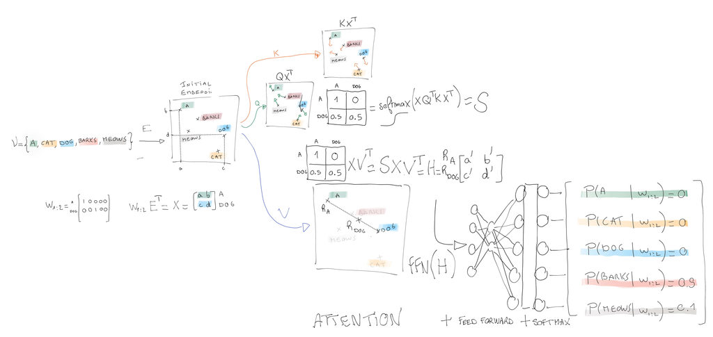

Self-attention block in auto-encoder

## Interpretation of Q, K, V

- The query is modified version of an initial embedding $q_i = Q x_i$
- The Key is modified version of an initial embedding $k_i = K x_i$
- Value is modified version of an initial embedding $v_i = V x_i$, which should include contextual information since it is a transformation of a linear combination of the context tokens…

| Attention Concept | Sometimes Similar to |
| --- | --- |
| Query | Target (What to focus on) |
| Key | Context (What to compare against, the source of information) |
| Value | Contextual embedding |

## Important details

The original paper introduces many add-ons, which much improve the transformers performances:

- **Positional encoding** for introducing the notion of order in the sequence
- FFN: **Feed Forward Neural layer**.
  - As the attention is a linear operation composed with a softmax, a Feed Forward Neural layer is added for making the function more flexible
- **Multi-blocks**: In the spirit of Deep learning blocks of attention and FNN are repeated…
- **Dropout layers** are used for prevenring overfitting (from “Dropout a simple way to prevent NN from overfitting” Hinton)
- Simple trick of **Skip connection** for stabilizing the gradient (from “Deep learning residuals for image recognition”)
  - The deep learning structure tends to cause problems with gradient computation (vanishing or exploding gradient)
- In order to make tokens comparable, they are all **normalized** at the output of each blocks:
  - The classical z-transformed is applied (with Bayesian correction)
- **Multi-head attention**: computes multiple attention functions (heads) in parallel

## Positional encoding

- Attention do not consider order of tokens !
- Incorporating information about the order of tokens is achieved by adding positional encodings to the input embeddings

The original transformer implementation uses:

- even indices:
  $$PE_{\text{pos}, 2i} = \sin\left(\frac{\text{pos}}{10000^{\frac{2i}{d}}}\right)$$
- odd indices:
  $$PE_{\text{pos}, 2i+1} = \cos\left(\frac{\text{pos}}{10000^{\frac{2i}{d}}}\right)$$

It ensures that each position is assigned a unique encoding

## Feed Forward Neural Network

- **Attention mechanism operates linearly** to capture dependencies between tokens in a sequence
- Non-linearity enhance the model’s expressive power

### Structure of the FFN:

Each FFN consists of two linear transformations with a non-linear activation function in between:

1. First Linear Transformation: embedding of the input from the model’s dimensionality $d$ to a higher-dimensional space
2. Activation Function: A non-linear function is applied to introduce non-linearity
3. Second Linear Transformation: projects the output back to the original dimensionality

$$\text{FFN}(x) = W_2 \cdot \text{ReLU}(W_1 \cdot x + b_1) + b_2$$

where $W_1$ and $W_2$ are weight matrices, and $b_1$ and $b_2$ are bias vectors.

## Skip connection (original paper “Deep Residual Learning for Image Recognition” 2015 by He et al.)

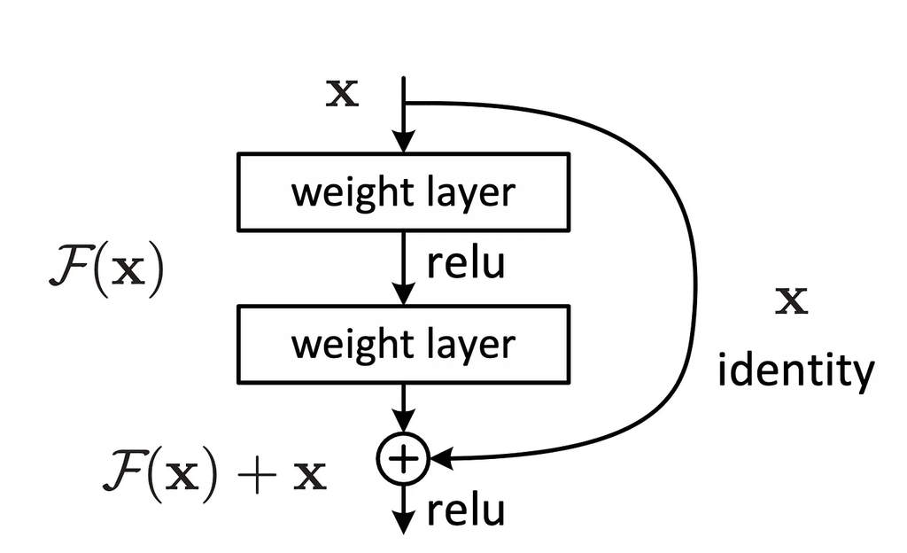

Skip connection

Skip connections address the vanishing (and exploding) gradient problems

- Consider a neural network layer with an input $x$ and a desired underlying function $H(x)$.
- Incorporating a skip connection, the layer is restructured to model a residual $F(x)= H(x)- x$. Thus, the output of this layer becomes:

$$y = F(x) + x$$

### Benefits:

- Enhanced Gradient Flow
- Faster convergence and higher accuracy

## Multi-head attention

- Multi-Head Attention captures various aspects of the data.
- The mechanism computes multiple attention functions (heads) in parallel.
- Each head operates on linearly projected versions of the queries, keys, and values

Each head $k$ computes the attention scores
$$\text{Attention}(Q_k, K_k, V_k) = \text{softmax}\left(\frac{XQ_k^T K_kX}{\sqrt{d_k}}\right)X V_k^T$$
where $d_k$ is the dimension of the key vectors

### Concatenation

The outputs of all heads are concatenated and projected through a final linear layer:
$$\text{MultiHead}(Q, K, V) = \text{Concat}(\text{head}_1, \ldots, \text{head}_h) P$$
The multi head matrix is $d \times d$, where - $h$ is the number of head, - $d_k= d/h$ the size of the projection space of head k - $P$ is a projection matrix combining the heads.

### Benefits

- Diverse Representations: Each head can capture different features or relationships within the data, enabling the model to understand various aspects of the input (grammar, style, “meaning”…).
  - Parallel Processing: Multiple heads allow the model to process different parts of the sequence simultaneously, improving efficiency.
  - Enhanced Capacity: By attending to information from different subspaces, the model can capture complex patterns and dependencies.

## Fine tuning

After a pretraining step that ressembles closely to a decoder…

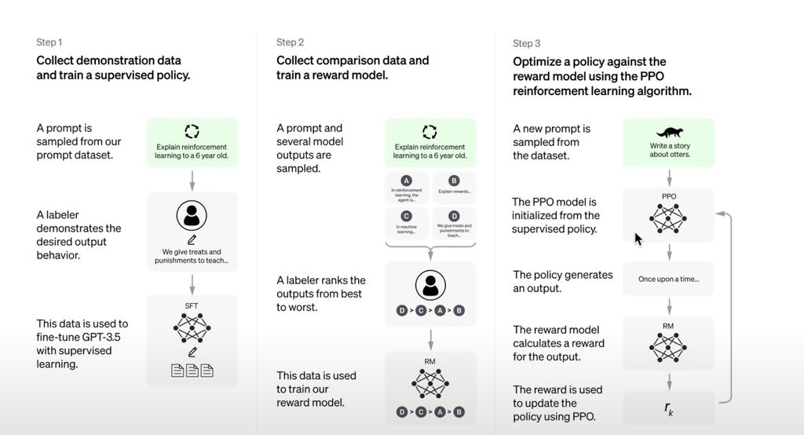

ChatGPT fine tuning (from A. Karpathy lecture)

# Exercices

## Schur Complement Lemma

Let A be a square matrix partitioned as follows:

$$A =
\begin{bmatrix}
A_{11} & A_{12} \\
A_{21} & A_{22}
\end{bmatrix}$$
Assuming that $A_{11}$ is invertible, the Schur complement of $A_{11}$ in A is defined as:

$$S = A_{22} - A_{21}A_{11}^{-1}A_{12}$$

The lemma states that if A is invertible, then A is invertible if and only if S is invertible. Additionally, the inverse of A can be expressed as:

1. Start with the matrix equation $AX = B$, where $A$ is invertible and partitioned as described above.
2. Write the equation using the partitioned form of matrix A:

$$\begin{bmatrix} A_{11} & A_{12} \\
A_{21} & A_{22}
\end{bmatrix}
\begin{bmatrix}
X_{1} \\
X_{2}
\end{bmatrix}
= \begin{bmatrix} B_{1} \\ B_{2} \end{bmatrix}$$

3. Apply block matrix operations to rewrite the equation:

$$\begin{align}
A_{11}X_{1} + A_{12}X_{2} = B_{1}\\
A_{21}X_{1} + A_{22}X_{2} = B_{2}
\end{align}$$

4. Solve the first equation for $X_{1}$:
   $$X_{1} = A_{11}^{-1}(B_{1} - A_{12}X_{2})$$
5. Substitute this value of $X_{1}$ into the second equation:
   $$A_{21}A_{11}^{-1}(B_{1} - A_{12}X_{2}) + A_{22} X_2 = B_{2}$$
6. Simplify the equation:
   $$S X_{2} = B_{2} - A_{21}A_{11}^{-1}B_{1}$$
7. We can see that the coefficient matrix for $X_{2}$ is the Schur complement, $S = A_{22} - A_{21}A_{11}^{-1}A_{12}$
8. Therefore, $X_{2}$ can be calculated as:
   $$X_{2} = S^{-1}(B_{2} - A_{21}A_{11}^{-1}B_{1})$$
9. Finally, we can substitute the values of $X_{1}$ and $X_{2}$ to obtain the solution vector $X$:
   $$X = \begin{bmatrix} X_{1} \\ X_{2}
   \end{bmatrix} =
   \begin{bmatrix} A_{11}^{-1}(B_{1} - A_{12}S^{-1}(B_{2} - A_{21}A_{11}^{-1}B_{1})) \\
   S^{-1}(B_{2} - A_{21}A_{11}^{-1}B_{1})
   \end{bmatrix}=$$
   $$=\begin{bmatrix} A_{11}^{-1}+A_{11}^{-1}A_{12}S^{-1}A_{21}A_{11}^{-1} & -A_{11}^{-1}A_{12}S^{-1}\\
   -S^{-1}A_{21}A_{11}^{-1} & S^{-1}
   \end{bmatrix}
   \begin{bmatrix} B_{1} \\
   B_{2} \end{bmatrix}$$
   This demonstrates the Schur complement lemma and its application in solving the matrix equation $AX = B$.

Memotechnic : Take the other block in the diagonal and then turn clockwise to find the product of the three other block: for $A_{11}$ we get $A_{11}-A_{12}A_{22}^{-1}A_{21}$

## Conditional Gaussian

Demonstrate the form of the distribution of $x_1 | x_2$ when both vectors are gaussian.

We have the joint gaussian distribution of$\begin{pmatrix}x_1 \\ x_2 \end{pmatrix}$:

$$\begin{pmatrix}x_1 \\ x_2 \end{pmatrix}\sim \mathcal N(\mu, \Sigma)$$
We can proceed in three step:

1. Compute $\Sigma^{-1}= \Lambda$ the concentration matrix
2. Write the joint distribution into a sum of marginal in $x_2$ and conditonal in $x_1$
3. Derive the conditional distribution.

### Concentration matrix

The joint covariance matrix is partitioned as:

$$\Sigma =
\begin{bmatrix}
\Sigma_{11} & \Sigma_{12} \\
\Sigma_{21} & \Sigma_{22}
\end{bmatrix}.$$

The concentration matrix$\Lambda =\Sigma^{-1}$can be expressed as:

$$\Lambda =
\begin{bmatrix}
\Lambda_{11} & \Lambda_{12} \\
\Lambda_{21} & \Lambda_{22}
\end{bmatrix},$$

where the blocks of the concentration matrix are given by:

$$\Lambda_{11} = (\Sigma_{11} - \Sigma_{12} \Sigma_{22}^{-1} \Sigma_{21})^{-1}, \quad
\Lambda_{12} = -\Lambda_{11} \Sigma_{12} \Sigma_{22}^{-1},$$

$$\Lambda_{21} = -\Sigma_{22}^{-1} \Sigma_{21} \Lambda_{11}, \quad
\Lambda_{22} = \Sigma_{22}^{-1} + \Sigma_{22}^{-1} \Sigma_{21} \Lambda_{11} \Sigma_{12} \Sigma_{22}^{-1}.$$

Here,$\Lambda_{11}$ is obtained using the Schur complement of $\Sigma_{11}$ in

$\Sigma$:

$$\Lambda_{11} = (\Sigma_{11} - \Sigma_{12} \Sigma_{22}^{-1} \Sigma_{21})^{-1}.$$

### Decompose the joint distribution

The quadratic form of the joint distribution decomposes as follow

$$Q = (x_1 - \mu_1)^T \Lambda_{11} (x_1 - \mu_1)
+ 2 (x_1 - \mu_1)^T \Lambda_{12} (x_2 - \mu_2) + (x_2 - \mu_2)^T \Lambda_{22} (x_2 - \mu_2)$$

Replacing the $\Lambda_{ij}$ with their expression in function of the $\Sigma_{ij}$, we eventually get

$$\begin{align}
Q =&
(x_1 - (\mu_1 + \Sigma_{12} \Sigma_{22}^{-1} (x_2 - \mu_2)))^T \Sigma_{1|2}^{-1} (x_1 - (\mu_1 + \Sigma_{12} \Sigma_{22}^{-1} (x_2 - \mu_2)))+\\
&(x_2 - \mu_2)^T \Sigma_{22}^{-1} (x_2 - \mu_2)
\end{align}$$

### Derive the conditional distribution

The joint distribution of$(x_1, x_2) \sim N(\mu, \Sigma)$, where

$$\mu =
\begin{bmatrix}
\mu_1 \\
\mu_2
\end{bmatrix},
\quad
\Sigma =
\begin{bmatrix}
\Sigma_{11} & \Sigma_{12} \\
\Sigma_{21} & \Sigma_{22}
\end{bmatrix},$$

can be expressed as a product of the marginal distribution of $x_2$and the conditional distribution of $x_1$ given $x_2$.

The joint log-probability is:
$$\log p(x_1, x_2) = \log p(x_2) + \log p(x_1 | x_2).$$

Expanding each term: 1. The marginal distribution of$x_2$:

$$p(x_2) \sim N(\mu_2, \Sigma_{22}),$$

with the log-density:

$$\log p(x_2) = -\frac{1}{2} (x_2 - \mu_2)^T \Sigma_{22}^{-1} (x_2 - \mu_2) - \frac{1}{2} \log |\Sigma_{22}| - \frac{d_2}{2} \log (2\pi).$$

2. The conditional distribution of$x_1$given$x_2$:

$$p(x_1 | x_2) \sim N(\mu_{1|2}, \Sigma_{1|2}),$$

where

$$\mu_{1|2} = \mu_1 + \Sigma_{12} \Sigma_{22}^{-1} (x_2 - \mu_2), \quad
\Sigma_{1|2} = \Sigma_{11} - \Sigma_{12} \Sigma_{22}^{-1} \Sigma_{21}.$$

The log-density is:

$$\log p(x_1 | x_2) = -\frac{1}{2} (x_1 - \mu_{1|2})^T \Sigma_{1|2}^{-1} (x_1 - \mu_{1|2}) - \frac{1}{2} \log |\Sigma_{1|2}| - \frac{d_1}{2} \log (2\pi).$$

Thus, the joint distribution can be written as:

$$\log p(x_1, x_2) = \log p(x_2) + \log p(x_1 | x_2).$$

## Stochastic Gradient and linear regression

The Mean Squared Error can be expressed as a sum of the available sample $(y_i,\boldsymbol x_i)_i$ :

$$Q(\boldsymbol w) = \frac{1}{n} \sum_i \| y_i - \boldsymbol{w^tx_i} \|^2 = \frac{1}{n} \sum_i Q_i(\boldsymbol w)$$

### The gradient

is expressed as

$$\nabla Q_i(\boldsymbol w) = -2 \boldsymbol x_i (y_i - \boldsymbol{w^tx_i})$$

### Online regression code

```r
library(ggplot2)
library(patchwork)  # Pour afficher les graphes côte à côte

# Fonction de régression linéaire séquentielle
regression.online <- function(X, Y, max.iteration = 300) {
  p <- ncol(X)
  n <- nrow(X)
  X <- cbind(1, X)  # Ajout de l'intercept

  shuffling <- sample(1:n, n)
  X <- X[shuffling, ]
  Y <- Y[shuffling]
  Q<-rep(0,max.iteration)
  W <- rep(0, p + 1)  # Initialisation des coefficients
  for (i in 1:max.iteration) {
    idx <- (i - 1) %% n + 1
    x <- drop(X[idx,])  # Sélection d'un point (matrice 1x(p+1))
    y <- Y[idx]
    W <- W + (1 / i) * x * (y - drop(rbind(W) %*% cbind(x)))  # Mise à jour du vecteur de poids
    Q[i]<-mean((Y - X %*% cbind(W))^2)
  }

  return(list(W=W,Q=Q))
}
```

### Comparison with batch approach

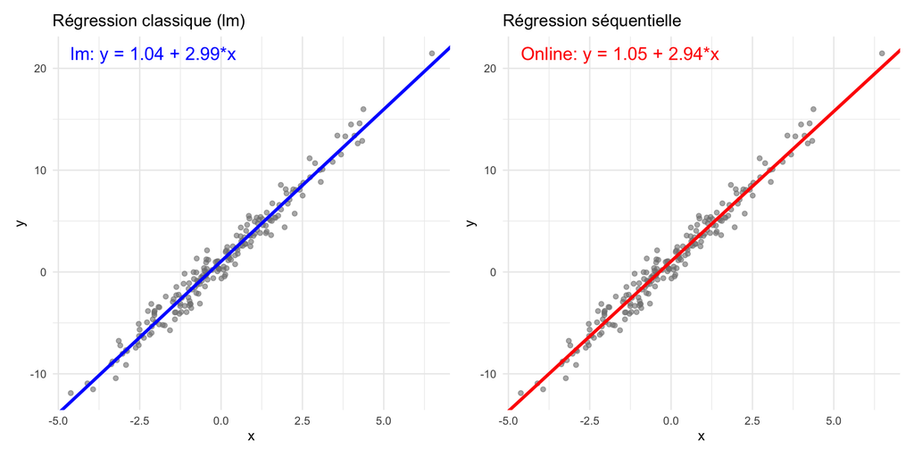

```r
# Génération des données
set.seed(123)
x <- rnorm(200, sd = 2)
y <- 1 + 3 * x + rnorm(200, sd = 1)

# Ajustement avec lm
lm_model <- lm(y ~ x)
lm_coef <- coef(lm_model)  # Coefficients de lm

# Ajustement avec la régression séquentielle
online_res <- regression.online(matrix(x, ncol = 1), y)
online_coef<-online_res$W

# Création d'un dataframe pour ggplot
df <- data.frame(x = x, y = y)

# Graphique 1 : Régression classique avec lm
p1 <- ggplot(df, aes(x = x, y = y)) +
  geom_point(color = "gray50", alpha = 0.6) +
  geom_abline(intercept = lm_coef[1], slope = lm_coef[2], color = "blue", lwd = 1.2) +
  annotate("text", x = min(x), y = max(y),
           label = sprintf("lm: y = %.2f + %.2f*x", lm_coef[1], lm_coef[2]),
           hjust = 0, color = "blue", size = 5) +
  labs(title = "Régression classique (lm)",
       x = "x", y = "y") +
  theme_minimal()

# Graphique 2 : Régression en ligne
p2 <- ggplot(df, aes(x = x, y = y)) +
  geom_point(color = "gray50", alpha = 0.6) +
  geom_abline(intercept = online_coef[1], slope = online_coef[2], color = "red", lwd = 1.2) +
  annotate("text", x = min(x), y = max(y),
           label = sprintf("Online: y = %.2f + %.2f*x", online_coef[1], online_coef[2]),
           hjust = 0, color = "red", size = 5) +
  labs(title = "Régression séquentielle",
       x = "x", y = "y") +
  theme_minimal()

# Affichage côte à côte
p1 + p2
```

### MSE minimisation

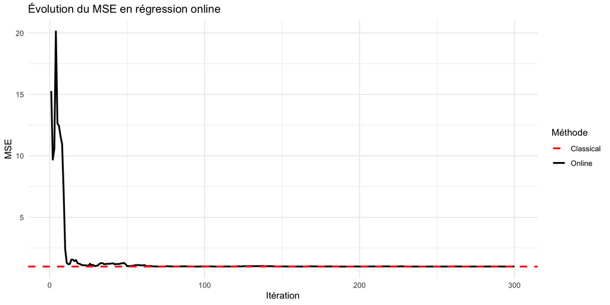

```r
library(ggplot2)

# Données pour la courbe de la régression online
df_online <- data.frame(
  MSE = online_res$Q,
  Iteration = 1:length(online_res$Q)
)

# MSE de la régression classique
mse_lm <- mean(lm_model$residuals^2)

# Graphique avec ggplot2
ggplot(df_online, aes(x = Iteration, y = MSE)) +
  geom_line(color = "black", size = 1, aes(linetype = "Online")) +  # Courbe Online en noir
  geom_hline(aes(yintercept = mse_lm, linetype = "Classical"), color = "red", size = 1) +  # Ligne lm en rouge
  scale_linetype_manual(name = "Méthode", values = c("Online" = "solid", "Classical" = "dashed")) +  # Légende
  labs(
    title = "Évolution du MSE en régression online",
    x = "Itération",
    y = "MSE"
  ) +
  theme_minimal()
```

## What is the KL (Kullback–Leibler) divergence between two multivariate Gaussian distributions?

[KL divergence](https://en.wikipedia.org/wiki/Kullback%E2%80%93Leibler_divergence) between two distributions $P$ and $Q$ of a continuous random variable is given by:

$$D_{KL}(p||q) = \int_x p(x) \log \frac{p(x)}{q(x)}$$

And probabilty density function of [multivariate Normal distribution](https://en.wikipedia.org/wiki/Multivariate_normal_distribution) is given by:

$$p(\mathbf{x}) = \frac{1}{(2\pi)^{k/2}|\Sigma|^{1/2}} \exp\left(-\frac{1}{2}(\mathbf{x}-\boldsymbol{\mu})^T\Sigma^{-1}(\mathbf{x}-\boldsymbol{\mu})\right)$$

Now, let our two Normal distributions be $\mathcal{N}(\boldsymbol{\mu_p},\,\Sigma_p)$ and $\mathcal{N}(\boldsymbol{\mu_q},\,\Sigma_q)$, both $k$ dimensional.

$$\begin{align}
D_{KL}(p||q) & = \mathbb{E}_p\left[\log(p) - \log(q)\right]
\newline
& = \mathbb{E}_p\left[\frac{1}{2}\log\frac{|\Sigma_q|}{|\Sigma_p|} - \frac{1}{2}(\mathbf{x}-\boldsymbol{\mu_p})^T\Sigma_p^{-1}(\mathbf{x}-\boldsymbol{\mu_p}) + \frac{1}{2}(\mathbf{x}-\boldsymbol{\mu_q})^T\Sigma_q^{-1}(\mathbf{x}-\boldsymbol{\mu_q})\right]
\newline
& = \frac{1}{2}\mathbb{E}_p\left[\log\frac{|\Sigma_q|}{|\Sigma_p|}\right] - \frac{1}{2}\mathbb{E}_p\left[(\mathbf{x}-\boldsymbol{\mu_p})^T\Sigma_p^{-1}(\mathbf{x}-\boldsymbol{\mu_p})\right] + \frac{1}{2}\mathbb{E}_p\left[(\mathbf{x}-\boldsymbol{\mu_q})^T\Sigma_q^{-1}(\mathbf{x}-\boldsymbol{\mu_q})\right]
\newline
& = \frac{1}{2}\log\frac{|\Sigma_q|}{|\Sigma_p|} - \frac{1}{2}\mathbb{E}_p\left[(\mathbf{x}-\boldsymbol{\mu_p})^T\Sigma_p^{-1}(\mathbf{x}-\boldsymbol{\mu_p})\right] + \frac{1}{2}\mathbb{E}_p\left[(\mathbf{x}-\boldsymbol{\mu_q})^T\Sigma_q^{-1}(\mathbf{x}-\boldsymbol{\mu_q})\right]
\end{align}$$

Now, since $(\mathbf{x}-\boldsymbol{\mu_p})^T\Sigma_p^{-1}(\mathbf{x}-\boldsymbol{\mu_p})$ in the second term $\in \mathbb{R}$, we can write it as $tr\left\{(\mathbf{x}-\boldsymbol{\mu_p})^T\Sigma_p^{-1}(\mathbf{x}-\boldsymbol{\mu_p})\right\}$, where $tr\{\}$ is the trace operator. And using the trace trick (eq 16 of section 1.1 from [Matrix Cookbook](https://www.math.uwaterloo.ca/~hwolkowi/matrixcookbook.pdf)), we can write it as $tr\left\{(\mathbf{x}-\boldsymbol{\mu_p})(\mathbf{x}-\boldsymbol{\mu_p})^T\Sigma_p^{-1}\right\}$.

The second term now is,

$$= \frac{1}{2}\mathbb{E}_p\left[tr\left\{(\mathbf{x}-\boldsymbol{\mu_p})(\mathbf{x}-\boldsymbol{\mu_p})^T\Sigma_p^{-1}\right\}\right]$$

The expectation and trace can be interchanged to get,

$$\begin{align}
& = \frac{1}{2}tr\left\{\mathbb{E}_p\left[(\mathbf{x}-\boldsymbol{\mu_p})(\mathbf{x}-\boldsymbol{\mu_p})^T\Sigma_p^{-1}\right]\right\}
\newline
& = \frac{1}{2}tr\left\{\mathbb{E}_p\left[(\mathbf{x}-\boldsymbol{\mu_p})(\mathbf{x}-\boldsymbol{\mu_p})^T\right]\Sigma_p^{-1}\right\}
\end{align}$$

We know $\mathbb{E}_p\left[(\mathbf{x}-\boldsymbol{\mu_p})(\mathbf{x}-\boldsymbol{\mu_p})^T\right] = \Sigma_p$. Simplifying it to

$$\begin{align}
& = \frac{1}{2}tr\left\{\Sigma_p\Sigma_p^{-1}\right\}
\newline
& = \frac{1}{2}tr\left\{I_k\right\}
\newline
& = \frac{k}{2}
\end{align}$$

We can simplify the third term

$$\begin{align}
\mathbb{E}_p\left[(\mathbf{x}-\boldsymbol{\mu_q})^T\Sigma_q^{-1}(\mathbf{x}-\boldsymbol{\mu_q})\right] &=& \mathbb{E}_p\left[(\mathbf{x}-\boldsymbol{\mu_p}+\boldsymbol{\mu_p}-\boldsymbol{\mu_q})^T\Sigma_q^{-1}(\mathbf{x}-\boldsymbol{\mu_p}+\boldsymbol{\mu_p}-\boldsymbol{\mu_q})\right] \\
&=& \mathbb{E}_p\left[(\boldsymbol{\mu_p}-\boldsymbol{\mu_q})^T\Sigma_q^{-1}(\boldsymbol{\mu_p}-\boldsymbol{\mu_q}) + tr\left\{\Sigma_q^{-1}\Sigma_p\right\} + 2 (\boldsymbol{\mu_p}-\boldsymbol{\mu_q})^T \Sigma_q^{-1}(\boldsymbol{\mu_p}-\boldsymbol{x} \right] \\
&=& (\boldsymbol{\mu_p}-\boldsymbol{\mu_q})^T\Sigma_q^{-1}(\boldsymbol{\mu_p}-\boldsymbol{\mu_q}) + tr\left\{\Sigma_q^{-1}\Sigma_p\right\}
\end{align}$$

Combining all this we get,

## Kullback–Leibler divergence between two multivariate Gaussian distributions

### Compact form

$$D_{KL}(p||q) = \frac{1}{2}\left[\log\frac{|\Sigma_q|}{|\Sigma_p|} - k + (\boldsymbol{\mu_p}-\boldsymbol{\mu_q})^T\Sigma_q^{-1}(\boldsymbol{\mu_p}-\boldsymbol{\mu_q}) + tr\left\{\Sigma_q^{-1}\Sigma_p\right\}\right]$$

### When $q$ is $\mathcal{N}(0,\,I)$

$$D_{KL}(p||q) = \frac{1}{2}\left[\boldsymbol{\mu_p}^T\boldsymbol{\mu_p} + tr\left\{\Sigma_p\right\} - k - \log|\Sigma_p|\right]$$